# HW 3

Author

Caitlin Worline

# Text Mining

## Set Up

```r
library(readr)
pubmed <- read_csv("pubmed.csv")
```

## Question 1

How many abstracts are associated with each search term? Tokenize the abstracts and count the number of each token. Do you see anything interesting? What are the 5 most common tokens for each search term?

### Summary

- The five most common tokens showed a similar pattern across the different search terms, with general scientific and biomedical vocabulary appearing frequently. While some topic-specific terminology was present, common stop words made up a large portion of the most frequent tokens.

```r
# Abstract Counts
library(tidyverse)
abstract_counts <-
  pubmed %>%
  count(term, sort = TRUE)

abstract_counts
```

```
# A tibble: 5 × 2
  term                n
  <chr>           <int>
1 covid             981
2 prostate cancer   787
3 preeclampsia      780
4 cystic fibrosis   376
5 meningitis        317
```

```r
# Tokenize abstracts
library(tidytext)

tokens <-
  pubmed %>%
  select(term, abstract) %>%
  unnest_tokens(word, abstract)

tokens
```

```
# A tibble: 555,169 × 2
   term  word
   <chr> <chr>
 1 covid background
 2 covid and
 3 covid aims
 4 covid many
 5 covid patients
 6 covid with
 7 covid coronavirus
 8 covid disease
 9 covid 2019
10 covid covid
# ℹ 555,159 more rows
```

```r
# Count all terms
token_counts <-
  tokens %>%
  count(term, word, sort = TRUE)

token_counts
```

```
# A tibble: 39,234 × 3
   term            word      n
   <chr>           <chr> <int>
 1 covid           the    9741
 2 covid           of     7668
 3 covid           covid  7275
 4 preeclampsia    the    7119
 5 covid           19     7035
 6 covid           and    6861
 7 preeclampsia    of     6837
 8 prostate cancer the    6100
 9 prostate cancer of     5682
10 preeclampsia    and    5255
# ℹ 39,224 more rows
```

```r
# Top 5 tokens for each term
top5_tokens <-
  token_counts %>%
  group_by(term) %>%
  slice_max(n, n = 5) %>%
  arrange(term, desc(n))

top5_tokens
```

```
# A tibble: 25 × 3
# Groups:   term [5]
   term            word      n
   <chr>           <chr> <int>
 1 covid           the    9741
 2 covid           of     7668
 3 covid           covid  7275
 4 covid           19     7035
 5 covid           and    6861
 6 cystic fibrosis the    2677
 7 cystic fibrosis of     2304
 8 cystic fibrosis and    1777
 9 cystic fibrosis in     1497
10 cystic fibrosis to     1011
# ℹ 15 more rows
```

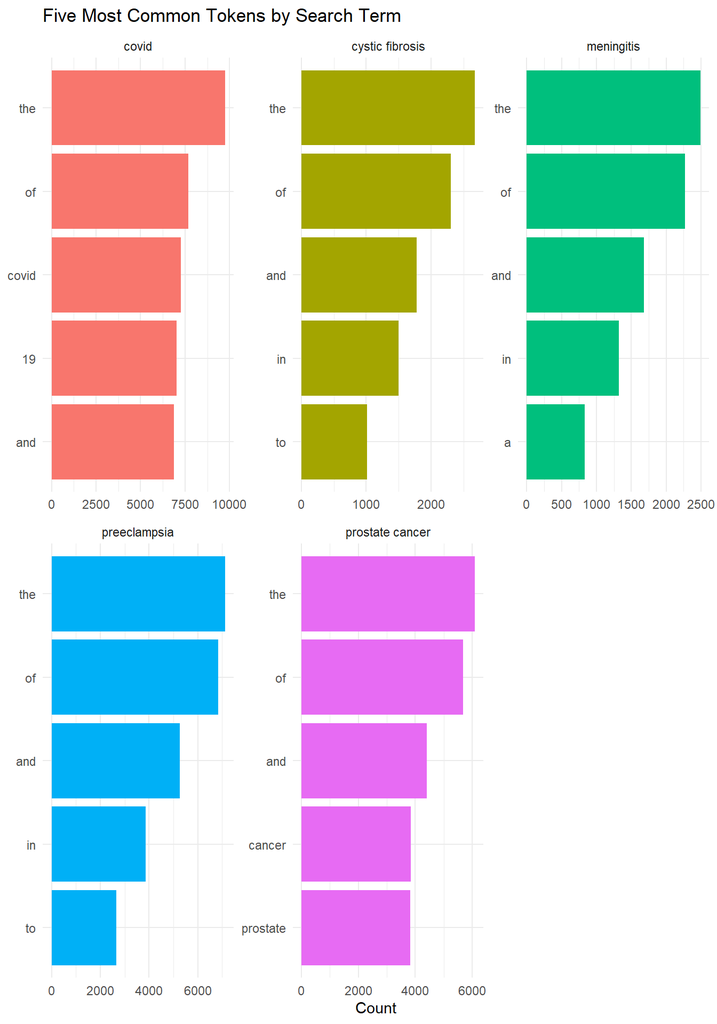

```r
# Top 5 tokens visualization
top5_tokens %>%
  mutate(word = reorder_within(word, n, term)) %>%
  ggplot(aes(n, word, fill = term)) +
  geom_col(show.legend = FALSE) +
  facet_wrap(~term, scales = "free") +
  scale_y_reordered() +
  labs(
    title = "Five Most Common Tokens by Search Term",
    x = "Count",
    y = NULL
  ) +
  theme_minimal()
```

## Question 2

Does removing stop words change what tokens appear as the most frequent? What are the 5 most common tokens for each search term after removing stop words?

### Summary

- After removing the stop words, the disease-specific terminology become much more visible. Instead of generic English words dominating the rankings, medically relevant terms associated with each search topic emerge as the most frequent tokens.

```r
# Remove the stop words
tidy_no_stop <-
  tokens %>%
  anti_join(stop_words, by = c("word"))

# Top 5 words after removing stop words
top5_no_stop <-
  tidy_no_stop %>%
  count(term, word, sort = TRUE) %>%
  group_by(term) %>%
  slice_max(n, n = 5)

top5_no_stop
```

```
# A tibble: 25 × 3
# Groups:   term [5]
   term            word         n
   <chr>           <chr>    <int>
 1 covid           covid     7275
 2 covid           19        7035
 3 covid           patients  2293
 4 covid           disease    943
 5 covid           pandemic   800
 6 cystic fibrosis fibrosis   867
 7 cystic fibrosis cystic     862
 8 cystic fibrosis cf         625
 9 cystic fibrosis patients   586
10 cystic fibrosis disease    400
# ℹ 15 more rows
```

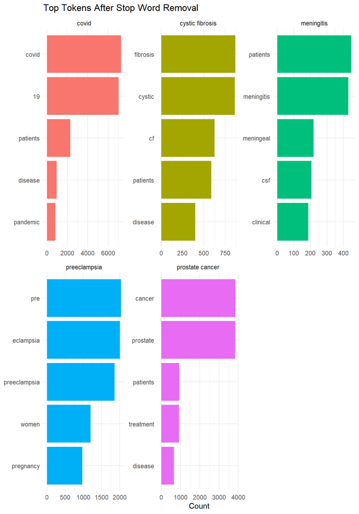

```r
# Updated top 5 tokens visualization
top5_no_stop %>%
  mutate(word = reorder_within(word, n, term)) %>%
  ggplot(aes(n, word, fill = term)) +
  geom_col(show.legend = FALSE) +
  facet_wrap(~term, scales = "free") +
  scale_y_reordered() +
  labs(
    title = "Top Tokens After Stop Word Removal",
    x = "Count",
    y = NULL
  ) +
  theme_minimal()
```

## Question 3

Tokenize the abstracts into bigrams. Find the 10 most common bigrams and visualize them. - Common English stop words were removed prior to calculating bigram frequencies to improve interpretation of the resulting word pairs.

```r
# Create and clean Bigrams
bigrams <-
  pubmed %>%
  unnest_tokens(
    bigram,
    abstract,
    token = "ngrams",
    n = 2
  ) %>%
  separate(
    bigram,
    into = c("word1", "word2"),
    sep = " "
  ) %>%
  filter(
    !word1 %in% stop_words$word,
    !word2 %in% stop_words$word
  ) %>%
  unite(
    bigram,
    word1,
    word2,
    sep = " "
  )

head(bigrams)
```

```
# A tibble: 6 × 2
  term  bigram
  <chr> <chr>
1 covid coronavirus disease
2 covid disease 2019
3 covid 2019 covid
4 covid covid 19
5 covid underlying cardiovascular
6 covid cardiovascular cv
```

```r
# Count Bigrams
bigram_counts <-
  bigrams %>%
  count(
    bigram,
    sort = TRUE
  )

head(bigram_counts)
```

```
# A tibble: 6 × 2
  bigram              n
  <chr>           <int>
1 covid 19         6969
2 prostate cancer  3222
3 pre eclampsia    1854
4 cystic fibrosis   860
5 19 patients       447
6 19 pandemic       419
```

```r
# Identify the most common Bigrams
top10_bigrams <-
  bigram_counts %>%
  slice_max(
    n,
    n = 10
  )

top10_bigrams
```

```
# A tibble: 10 × 2
   bigram                  n
   <chr>               <int>
 1 covid 19             6969
 2 prostate cancer      3222
 3 pre eclampsia        1854
 4 cystic fibrosis       860
 5 19 patients           447
 6 19 pandemic           419
 7 coronavirus disease   361
 8 95 ci                 322
 9 sars cov              317
10 cov 2                 299
```

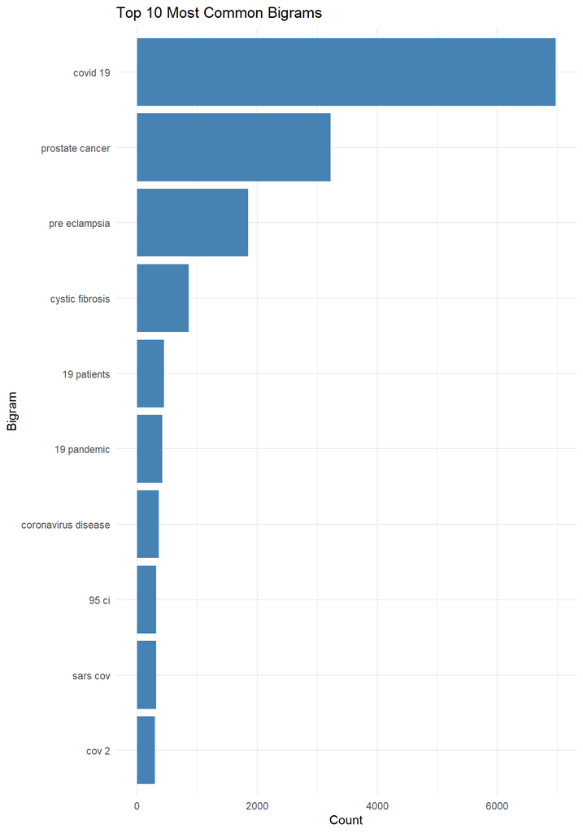

```r
# Top 10 Bigrams Visualization
top10_bigrams %>%
  mutate(
    bigram = reorder(
      bigram,
      n
    )
  ) %>%
  ggplot(
    aes(
      x = n,
      y = bigram
    )
  ) +
  geom_col(
    fill = "steelblue"
  ) +
  labs(
    title = "Top 10 Most Common Bigrams",
    x = "Count",
    y = "Bigram"
  ) +
  theme_minimal()
```

## Question 4

Calculate the TF-IDF value for each word-search term combination (here you want the search term to be the “document”). What are the 5 tokens from each search term with the highest TF-IDF value? How are the results different from the answers you got in Question 1?

### Summary

- The TF-IDF results differ from Question 1 because they highlight terms that are more distinctive and relevant to each search topic rather than simply identifying the most frequently occurring words. In Question 1, common scientific terms and general biomedical vocabulary appeared frequently across the abstracts. However, TF-IDF gives greater importance to words that are more specific to a particular topic and less common across the overall collection of abstracts.

```r
# Count words in each term
word_counts <-
  tidy_no_stop %>%
  count(term, word)

# Calculate TF-IDF
tfidf_tbl <-
  word_counts %>%
  bind_tf_idf(
    word,
    term,
    n
  ) %>%
  arrange(desc(tf_idf))

tfidf_tbl
```

```
# A tibble: 36,857 × 6
   term            word             n      tf   idf tf_idf
   <chr>           <chr>        <int>   <dbl> <dbl>  <dbl>
 1 covid           covid         7275 0.0647  1.61  0.104
 2 prostate cancer prostate      3832 0.0563  1.61  0.0906
 3 preeclampsia    eclampsia     2005 0.0255  1.61  0.0411
 4 preeclampsia    preeclampsia  1863 0.0237  1.61  0.0382
 5 meningitis      meningitis     429 0.0164  1.61  0.0264
 6 cystic fibrosis cf             625 0.0234  0.916 0.0215
 7 cystic fibrosis fibrosis       867 0.0325  0.511 0.0166
 8 cystic fibrosis cystic         862 0.0323  0.511 0.0165
 9 meningitis      meningeal      219 0.00837 1.61  0.0135
10 covid           pandemic       800 0.00711 1.61  0.0114
# ℹ 36,847 more rows
```

```r
# Top 5 terms per topic
top_tfidf <-
  tfidf_tbl %>%
  group_by(term) %>%
  slice_max(tf_idf, n = 5)

top_tfidf
```

```
# A tibble: 25 × 6
# Groups:   term [5]
   term            word            n      tf   idf  tf_idf
   <chr>           <chr>       <int>   <dbl> <dbl>   <dbl>
 1 covid           covid        7275 0.0647  1.61  0.104
 2 covid           pandemic      800 0.00711 1.61  0.0114
 3 covid           coronavirus   647 0.00575 1.61  0.00926
 4 covid           sars          372 0.00331 1.61  0.00532
 5 covid           cov           334 0.00297 1.61  0.00478
 6 cystic fibrosis cf            625 0.0234  0.916 0.0215
 7 cystic fibrosis fibrosis      867 0.0325  0.511 0.0166
 8 cystic fibrosis cystic        862 0.0323  0.511 0.0165
 9 cystic fibrosis cftr           86 0.00322 1.61  0.00518
10 cystic fibrosis sweat          83 0.00311 1.61  0.00500
# ℹ 15 more rows
```

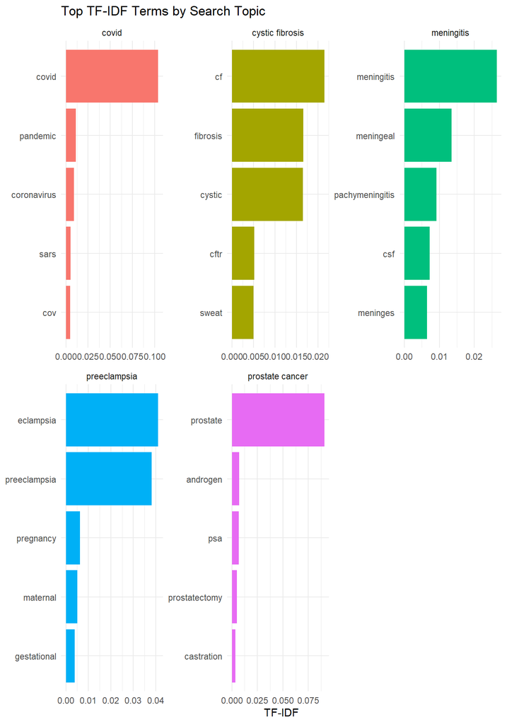

```r
# Top TF-IDF Visualization
top_tfidf %>%
  mutate(
    word =
      reorder_within(
        word,
        tf_idf,
        term
      )
  ) %>%
  ggplot(
    aes(
      tf_idf,
      word,
      fill = term
    )
  ) +
  geom_col(show.legend = FALSE) +
  facet_wrap(~term, scales = "free") +
  scale_y_reordered() +
  labs(
    title = "Top TF-IDF Terms by Search Topic",
    x = "TF-IDF",
    y = NULL
  ) +
  theme_minimal()
```

# Sentiment Analysis

## Question 5

Perform a sentiment analysis using the NRC lexicon. What is the most common sentiment for each search term? What if you remove “positive” and “negative” from the list?

### Summary

- When positive and negative sentiments were included, they accounted for the highest counts across most search topics. However, after removing them, more specific emotional patterns became visible. Fear was the most common remaining sentiment for COVID, meningitis, and prostate cancer, while disgust was most common for cystic fibrosis and anticipation was most common for preeclampsia.

```r
# Load NRC
nrc <- get_sentiments("nrc")

# Join sentiment labels
nrc_sentiment <-
  tidy_no_stop %>%
  inner_join(
    nrc,
    by = c("word")
  )
# Count sentiments
sentiment_counts <-
  nrc_sentiment %>%
  count(
    term,
    sentiment,
    sort = TRUE
  )

sentiment_counts
```

```
# A tibble: 50 × 3
   term            sentiment     n
   <chr>           <chr>     <int>
 1 covid           positive   9254
 2 covid           negative   9067
 3 prostate cancer negative   8799
 4 prostate cancer fear       8039
 5 preeclampsia    positive   7603
 6 covid           fear       7373
 7 preeclampsia    negative   6836
 8 prostate cancer positive   6688
 9 prostate cancer sadness    6284
10 prostate cancer anger      5794
# ℹ 40 more rows
```

```r
# Common sentiments per term
sentiment_counts %>%
  group_by(term) %>%
  slice_max(n, n = 1)
```

```
# A tibble: 5 × 3
# Groups:   term [5]
  term            sentiment     n
  <chr>           <chr>     <int>
1 covid           positive   9254
2 cystic fibrosis positive   2564
3 meningitis      negative   1961
4 preeclampsia    positive   7603
5 prostate cancer negative   8799
```

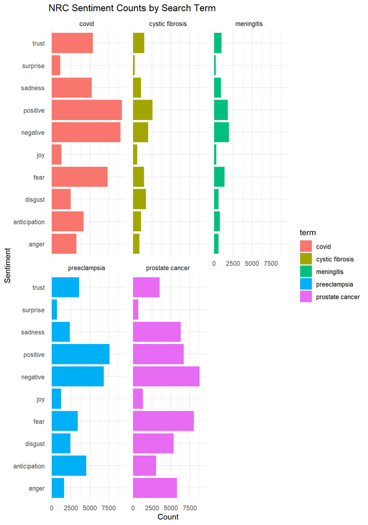

```r
# Most Common sentiment Plot
sentiment_counts %>%
  ggplot(
    aes(
      x = sentiment,
      y = n,
      fill = term
    )
  ) +
  geom_col() +
  facet_wrap(~term) +
  coord_flip() +
  labs(
    title = "NRC Sentiment Counts by Search Term",
    x = "Sentiment",
    y = "Count"
  ) +
  theme_minimal()
```

```r
# Remove Positive & Negative
sentiment_no_pn <-
  nrc_sentiment %>%
  filter(
    !sentiment %in% c(
      "positive",
      "negative"
    )
  )

# Count remaining sentiments
sentiment_no_pn_counts <-
  sentiment_no_pn %>%
  count(
    term,
    sentiment,
    sort = TRUE
  )

sentiment_no_pn_counts
```

```
# A tibble: 40 × 3
   term            sentiment        n
   <chr>           <chr>        <int>
 1 prostate cancer fear          8039
 2 covid           fear          7373
 3 prostate cancer sadness       6284
 4 prostate cancer anger         5794
 5 covid           trust         5413
 6 prostate cancer disgust       5374
 7 covid           sadness       5270
 8 preeclampsia    anticipation  4555
 9 covid           anticipation  4175
10 preeclampsia    trust         3594
# ℹ 30 more rows
```

```r
# Most common sentiments w/o + or -
sentiment_no_pn_counts %>%
  group_by(term) %>%
  slice_max(
    n,
    n = 1
  )
```

```
# A tibble: 5 × 3
# Groups:   term [5]
  term            sentiment        n
  <chr>           <chr>        <int>
1 covid           fear          7373
2 cystic fibrosis disgust       1714
3 meningitis      fear          1371
4 preeclampsia    anticipation  4555
5 prostate cancer fear          8039
```

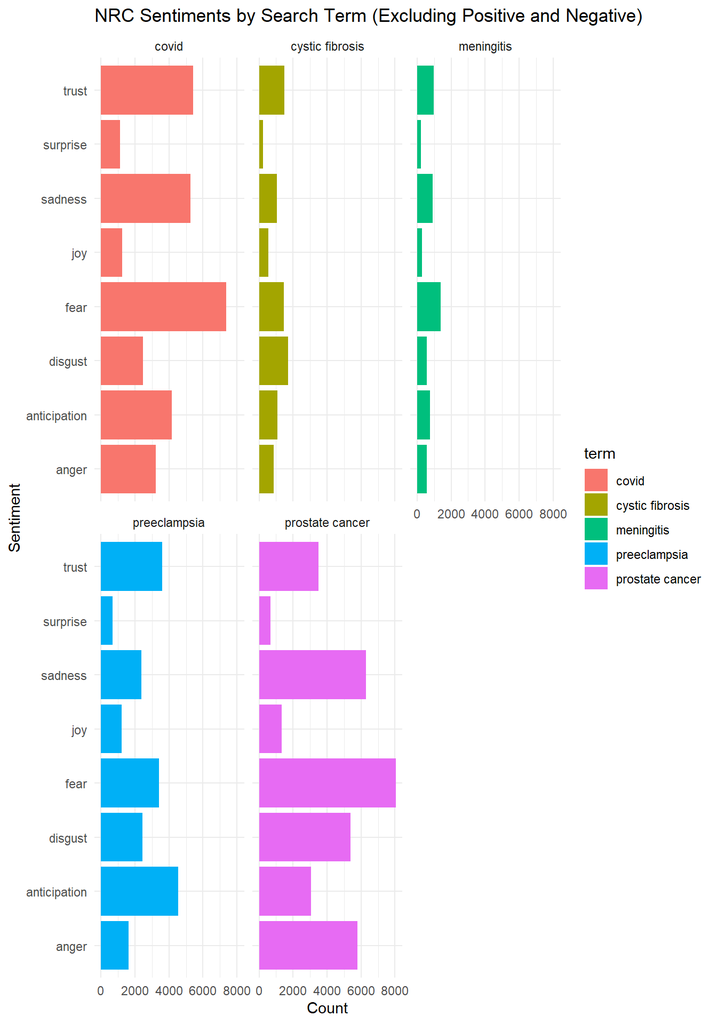

```r
# Sentiments w/o + or - Plot
sentiment_no_pn_counts %>%
  ggplot(
    aes(
      x = sentiment,
      y = n,
      fill = term
    )
  ) +
  geom_col() +
  facet_wrap(~term) +
  coord_flip() +
  labs(
    title = "NRC Sentiments by Search Term (Excluding Positive and Negative)",
    x = "Sentiment",
    y = "Count"
  ) +
  theme_minimal()
```

## Question 6

Perform a sentiment analysis using the AFINN lexicon to get an average positivity score for each abstract (hint: you may want to create a variable that indexes, or counts, the abstracts). Create a visualization that shows these scores grouped by search term. Are any search terms noticeably different from the others?

### Summary

- Yes, these terms are noticeably different. Cystic fibrosis stands out because it has the highest median sentiment score, which is slightly positive compared with the other search terms, whose median scores are slightly negative. Prostate cancer also has a noticeably narrower distribution, suggesting less variation in sentiment scores across its abstracts.

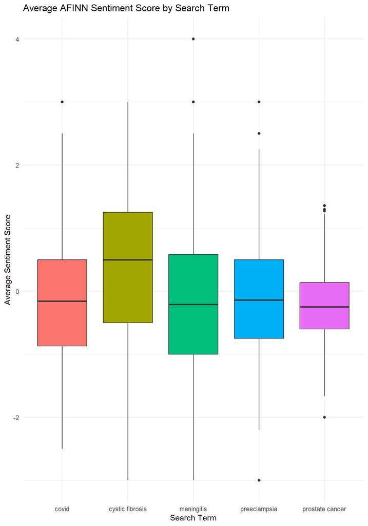

```r
# Create unique abstract IDs
unique_pubmed <-
  pubmed %>%
  mutate(
    abstract_id = row_number()
  )

# Tokenize abstracts
afinn_tokens <-
  unique_pubmed %>%
  unnest_tokens(
    word,
    abstract
  )

# Join AFFIN lexicon
afinn_scores <-
  afinn_tokens %>%
  inner_join(
    get_sentiments("afinn"),
    by = c("word")
  )

# Calculate AVG sentiment score per abstract
abstract_sentiment <-
  afinn_scores %>%
  group_by(
    abstract_id,
    term
  ) %>%
  summarise(
    mean_score = mean(value),
    .groups = "drop"
  )

# AFINN Sentiment Visualization
ggplot(
  abstract_sentiment,
  aes(
    x = term,
    y = mean_score,
    fill = term
  )
) +
  geom_boxplot() +
  labs(
    title = "Average AFINN Sentiment Score by Search Term",
    x = "Search Term",
    y = "Average Sentiment Score"
  ) +
  theme_minimal() +
  theme(
    legend.position = "none"
  )
```